LABORATORIUM 1

- Funkcje
  - Definiowanie funkcji w języku R
  - Zmienne w funkcjach
  - Argumenty funkcji
- Atrybuty
  - Odczytywanie i ustawianie atrybutów
  - Atrybuty specjalne
  - Przetwarzanie obiektów z atrybutami
- Testy jednostkowe
- Obsługa wyjątków
- Debuggowanie

### **Funkcje**

Paradygmant programowania funkcjonalnego wyróżnia funkcje jako najważniejsze składniki programu. Każde obliczenie jest traktowane jak matematyczna funkcja, której wynik zależy tylko i wyłącznie od danych wejściowych. Rozważmy przykładową funkcję `f`, która oblicza wartość stałej $\pi$ poprzez zsumowanie $n+1$ pierwszych elementów szeregu Leibniza, $\pi = 4 \sum_{i=0}^{\infty} (-1)^i/(2i+1)$.

```r
f <- function(n) 4*sum (c (1,-1) / (2*(0:n)+1))
f (1000)
```

```
## [1] 3.142592
```

Funkcja `f` jest zbudowana z predefiniowanych elementów, które również są funkcjami: `*, sum(), c(), /, +`. Każda z tych funkcji ma zdefiniowane argumenty oraz zwraca jasno określoną wartość:

- `+, *, /`: $\mathbb{R}^i\times \mathbb{R}^j \rightarrow \mathbb{R}^{\text{max} \{i,j\}}$
- `sum()`: $\mathbb{R}^i \rightarrow \mathbb{R}$
- `c()`: $\mathbb{R}^{i_1}\times \mathbb{R}^{i_2}\times \ldots\times \mathbb{R}^{i_k} \rightarrow \mathbb{R}^{i_1+i_2+\ldots+i_k}$

Funkcja `f` może być zatem zapisana również jako

```r
f <- function(n) `*` (4, sum (`/` (c(1, -1), `+` (`*` (2, `:` (0, n)), 1))))
f (1000)
```

```
## [1] 3.142592
```

#### **Definiowanie funkcji w języku R**

Aby zdefiniować funkcję należy wykonać poniższą komendę

```r
function (lista_parametrów) ciało
```

gdzie:

- `ciało` jest wyrażeniem w języku R wykonywanym *na* danych argumentach. Wynikowy obiekt jest wartością zwracaną przez funkcję.
- `lista_parametrów` jest oddzieloną przecinkami listą elementów w postaci:
  - “nazwa_parametru”,
  - “nazwa_parametru = wartość_domyślna”, lub
  - “…”.

Warto zauważyć, że do funkcji nie musi być przypisana żadna nazwa.

```r
(function(x) x^2)(1:5) # kwadrat
```

```
## [1]  1  4  9 16 25
```

W powyższym przykładzie zastosowaliśmy funkcję *anonimową* do wektora `1:5`. Funkcje anonimowe są szczególnie przydatne w połączeniu z funkcjami z rodziny `*apply`.

```r
lapply(list(1:3, 4:6), function(x) x^2)
```

```
## [[1]]
## [1] 1 4 9
##
## [[2]]
## [1] 16 25 36
```

Najczęściej jednak będziemy posługiwali się `nazwanymi` funkcjami.

```r
square <- function(x) x^2
square (1:5)
```

```
## [1]  1  4  9 16 25
```

```r
is.function (square)
```

```
## [1] TRUE
```

```r
is.atomic (square)
```

```
## [1] FALSE
```

```r
is.vector (square)
```

```
## [1] FALSE
```

```r
is.recursive (square)
```

```
## [1] TRUE
```

```r
typeof (square)
```

```
## [1] "closure"
```

```r
mode (square)
```

```
## [1] "function"
```

```r
square
```

```
## function(x) x^2
```

`Ciało` funkcji stanowi pojedyncze wyrażenie. Wiele wyrażeń może być zgrupowanych przy pomocy nawiasów klamrowych. Co ciekawe `{` też jest funkcją. Zwraca wartość będącą wynikiem ostatniego wyrażenia.

```r
`{`(1, 2, 3)
```

```
## [1] 3
```

```r
{
  1
  2
  3
}
```

```
## [1] 3
```

Każda funkcja musi coś zwracać. W niektórych przypadkach chcemy napisać funkcję, która coś zapisuje lub rysuje i niekoniecznie ma cokolowiek zwracać. Wtedy wygodnie jest użyć funkcji `invisible (x=NULL)`.

```r
printvec <- function(x) {
  cat (x, sep = ", ")
  cat ("\n")
  invisible ()
}

val <- printvec(1:4)
```

```
## 1, 2, 3, 4
```

```r
val
```

[output not shown]

#### **Zmienne w funkcjach**

Każde przypisanie wartości operatorem `<-` wewnątrz funkcji jest lokalne.

```r
g <- function(x) {
  gy <- x+1
}
g(3)
gy
```

```
## Error in eval(expr, envir, enclos): object 'gy' not found
```

Zmienna `gy` istnieje tylko wewnątrz funkcji `g()`. Możliwe jest jednak odnoszenie się wewnątrz funkcji do zmiennych globalnych, a nawet ich zmienianie operatorem `<<-`. Takie postępowanie jest jednak stanowczo odradzane, bo może generować problemy z utrzymaniem i rozwojem kodu.

```r
g <- function(x) {
  z <<- x + y
}
z <- 0
y <- 5
z <- g(1:5)
z
```

```
## [1]  6  7  8  9 10
```

#### **Argumenty funkcji**

W języku R można przekazać do każdej funkcji dowolny obiekt. To nie oznacza jednak, że funkcja musi go zaakceptować.

```r
square (square)
```

```
## Error in x^2: non-numeric argument to binary operator
```

```r
square (c ("a", "b"))
```

```
## Error in x^2: non-numeric argument to binary operator
```

```r
square (list (1, 2, 3))
```

```
## Error in x^2: non-numeric argument to binary operator
```

To po stronie programisty jest odpowiedzialność, aby przekazywać właściwe obiekty do funkcji. W takiej sytuacji bardzo przydatną funkcją jest `stopifnot (cond_1, cond_2, ..., cond_n)`, która wyrzuci błąd jeśli któryś z warunków nie jest spełniony.

```r
mean2 <- function (x) {
  stopifnot(is.numeric(x))
  stopifnot(length(x) > 0, is.finite(x))
  mean (x, na.rm=TRUE)
}

mean (numeric())
```

```
## [1] NaN
```

```r
mean2 (numeric())
```

```
## Error in mean2(numeric()): length(x) > 0 is not TRUE
```

```r
mean ( c(1,2,3,Inf))
```

```
## [1] Inf
```

```r
mean2 ( c(1,2,3,Inf))
```

```
## Error in mean2(c(1, 2, 3, Inf)): is.finite(x) are not all TRUE
```

Argumenty są przekazywane do funkcji przez wartość. Wewnątrz funkcji działają jak zmienne lokalne. Ich zmiana w funkcji nie powoduje zmiany ich wartości globalnej.

```r
squareroot <- function(x) {
  x <- sqrt(x)
  x
}

x <- 2
squareroot (x)
```

```
## [1] 1.414214
```

```r
x
```

```
## [1] 2
```

Przy definiowaniu funkcji można określić jej domyślne argumenty. Jeśli przy użyciu funkcji argument zostanie pominięty, to wykorzystana zostanie jego domyślna wartość.

```r
f <- function (a=1, b=2) a*b

f()
```

```
## [1] 2
```

```r
f(3,)
```

```
## [1] 6
```

```r
f(,4)
```

```
## [1] 4
```

```r
f(3,4)
```

```
## [1] 12
```

Argumenty domyślne (o ile występują) powinny być podawane na końcu listy argumentów. Ze względów optymalizacyjnych argumenty funkcji nie są używane dopóki nie są potrzebne.

```r
f <- function(x) {
  cat("before ")
  cat(x)
  cat(" after\n")
}

f(1)
```

```
## before 1 after
```

```r
f({cat("now "); 1})
```

```
## before now 1 after
```

Takie zachowanie nazywa się *wartościowaniem leniwym* (ang. *lazy evaluation*). Niektóre argumenty mogą zostać nigdy nie wykorzystane. Można łatwo sprawdzić czy argument został pominięty przy wywołaniu funkcji.

```r
f <- function(x = 1) {
  cat(missing(x), x)
}
f(1)
```

```
## FALSE 1
```

```r
f(2)
```

```
## FALSE 2
```

```r
f()
```

```
## TRUE 1
```

Ponadto, przy pomocy funkcji `match.arg()` możemy kazać naszej funkcji akceptować tylko wybrane wartości typu `character`. Użycie pierwszych liter jest wystarczające o ile argumenty dają się rozróżnić.

```r
f <- function(kierunek = c("prawo", "lewo", "przód", "tył")) {
  kierunek <- match.arg(kierunek)
  kierunek
}
f("prawo")
```

```
## [1] "prawo"
```

```r
f("p")
```

```
## Error in match.arg(kierunek): 'arg' should be one of "prawo", "lewo", "przód", "tył"
```

```r
f("l")
```

```
## [1] "lewo"
```

```r
f("pra")
```

```
## [1] "prawo"
```

```r
f("ód")
```

```
## Error in match.arg(kierunek): 'arg' should be one of "prawo", "lewo", "przód", "tył"
```

```r
f("góra")
```

```
## Error in match.arg(kierunek): 'arg' should be one of "prawo", "lewo", "przód", "tył"
```

Możemy również dowiedzieć się jakie wyrażenie zostało przekazane do funkcji jako jej argument.

```r
f <- function(x) cat (deparse (substitute (x)), "=", x)
f (5)
```

```
## 5 = 5
```

```r
vals <- 1:5
f (vals)
```

```
## vals = 1 2 3 4 5
```

```r
f (round (log (vals^2) + vals, 1))
```

```
## round(log(vals^2) + vals, 1) = 1 3.4 5.2 6.8 8.2
```

Jest to często wykorzystywane w funkcjach graficznych.

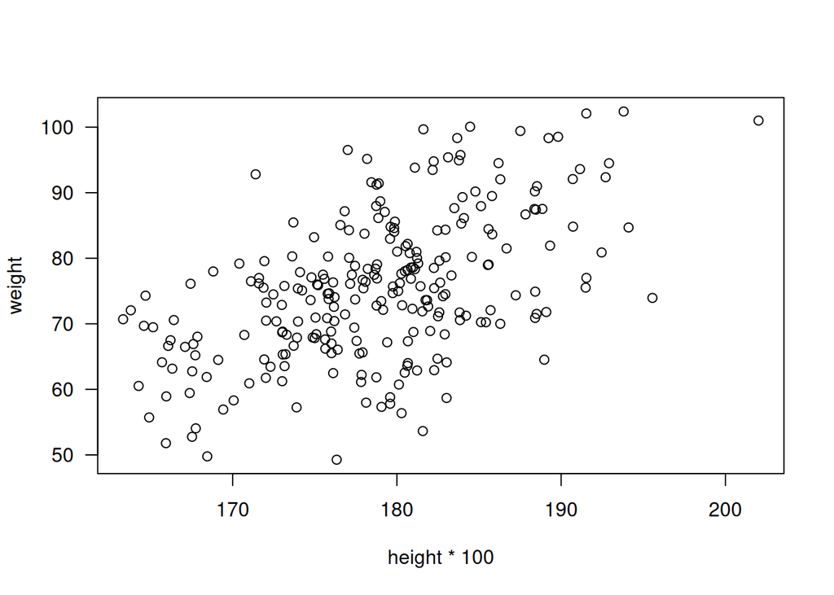

```r
height <- rnorm (250, 1.79, 0.07)
weight <- rnorm (250, 23, 3) * height^2
plot (height * 100, weight, las = 1) # zwróć uwagę na etykiety osi
```

Parametr `...` (*dot-dot-dot*) grupuje wiele argumentów w jeden. Pozwala na tworzenie funkcji, które przyjmują (a priori) nieznaną liczbę parametrów lub ułatwia przekazywanie zbioru parametrów do innej funkcji. Do każdego argumentu zgrupowanego w `...` może dostać się operatorem dwóch kropek: `..1, ..2, ...`.

```r
f <- function(...) {
  print(..1)
  print(..2)
}
f (1,2,3)
```

```
## [1] 1
## [1] 2
```

```r
f (1)
```

```
## [1] 1
```

```
## Error in print(..2): the ... list contains fewer than 2 elements
```

Argument `...` może być łatwo przekonwertowany na listę. Funkcja `str()` w przejrzysty sposób wyświetla dowolną strukturę w języku R.

```r
f <- function(...) {
  list (...)
}
str (f (1,2,3))
```

```
## List of 3
##  $ : num 1
##  $ : num 2
##  $ : num 3
```

Trójkropek może być również przekazany do innej funkcji. Przykładowe funkcje wykorzystujące trójkropek to `c(), list(), sum(), mean(), cbind(), rbind()`.

```r
f <- function(x, g, ...) {
  x + g (...)
}
f(1, c, 10, 20, 30)
```

```
## [1] 11 21 31
```

```r
f(1, sum, 2, 3)
```

```
## [1] 6
```

### **Atrybuty**

Prawie wszystkie obiekty (za wyjątkiem `NULL`) w języku R mogą być wyposażone w atrybuty. Atrybuty są w pewnym sensie metadanymi, tzn. zawierają dodatkowe informacje o obiektach. Ustawienie niektórych atrybutów może mieć istotny wpływ na to jak obiekt oddziałuje z funkcjami.

#### **Odczytywanie i ustawianie atrybutów**

Funkcja `attr ()` może służyć do ustawiania atrybutów. Atrybut jest parą klucz-wartość. Za wyjątkiem kilku specjalnych atrybutów możemy dowolnie dodawać metadane do obiektów języku R.

```r
x <- (-5):5
attr(x, "kolor") <- "green"
attr(x, "ktore_dodatnie") <- which(x > 0)
attr(x, "ulubiona_funkcja") <- exp
```

Powyższy kod jest równoważny poniższemu.

```r
x <- structure((-5):5,
               kolor = "green",
               ktore_dodatnie = which(x > 0),
               ulubiona_funkcja = exp
               )
```

Funkcja `attr ()` może być też używana do odczytywania atrybutów obiektu.

```r
attr (x, "kolor")
```

```
## [1] "green"
```

```r
attr (x, "ktore_dodatnie")
```

```
## [1]  7  8  9 10 11
```

```r
attr (x, "ulubiona_funkcja")
```

```
## function (x)  .Primitive("exp")
```

Warto zwrócić uwagę jak wypisywany jest obiekt z dodanymi metadanymi.

```r
x
```

```
##  [1] -5 -4 -3 -2 -1  0  1  2  3  4  5
## attr(,"kolor")
## [1] "green"
## attr(,"ktore_dodatnie")
## [1]  7  8  9 10 11
## attr(,"ulubiona_funkcja")
## function (x)  .Primitive("exp")
```

```r
str (x)
```

```
##  int [1:11] -5 -4 -3 -2 -1 0 1 2 3 4 ...
##  - attr(*, "kolor")= chr "green"
##  - attr(*, "ktore_dodatnie")= int [1:5] 7 8 9 10 11
##  - attr(*, "ulubiona_funkcja")=function (x)
```

Najważniejsze jednak, że `x` jest nadal “zwyczajnym” wektorem numerycznym i dlatego można na nim wykonywać dokładnie te same operacje co na innych wektorach numerycznych.

```r
mode (x)
```

```
## [1] "numeric"
```

```r
typeof (x)
```

```
## [1] "integer"
```

```r
x[1]
```

```
## [1] -5
```

```r
mean (x)
```

```
## [1] 0
```

```r
x[attr (x, "ktore_dodatnie")]
```

```
## [1] 1 2 3 4 5
```

Aby usunąć atrybut wystarczy przypisać do niego wartość `NULL`.

```r
attr (x, "ulubiona_funkcja") <- NULL
x
```

```
##  [1] -5 -4 -3 -2 -1  0  1  2  3  4  5
## attr(,"kolor")
## [1] "green"
## attr(,"ktore_dodatnie")
## [1]  7  8  9 10 11
```

Innym sposobem na zapoznanie się ze wszystkimi atrybutami jest funkcja `attributes ()`, która zwraca nazwaną listę.

```r
attributes (x)
```

```
## $kolor
## [1] "green"
##
## $ktore_dodatnie
## [1]  7  8  9 10 11
```

#### **Atrybuty specjalne**

Istnieją w języku R pewne atrybuty specjalne. Ich wartości muszą spełniać pewne ograniczenia. Są to m.in.:

- `comment` - ignorowany przez `print()`; typ `character`,
- `names` - nazwy elementów wektora; typ `character vector`,
- `class` - obiekt klasy S3; typ `character`,
- `dim` - określa wymiarowość macierzy czyli liczbę kolumn i wierszy; typ `numeric vector`,
- `dimnames` - nazwy wymiarów macierzy; typ `character vector`,
- `row.names` - nazwy wierszy macierzy lub ramki danych; typ `character vector`,
- `colnames` - nazwy kolumn macierzy lub ramki danych; typ `character vector`.

Atrybuty specjalne posiadają swoje własne funkcje przy pomocy których możemy je ustawiać lub odczytywać.

##### Atrybut comment

Rolą atrybutu specjalnego `comment` jest przechowywać metainformację niewidoczną podczas zwykłego wyświetlania obiektu.

```r
x <- 1:5
comment (x) <- "Ukryta wiadomość"
x
```

```
## [1] 1 2 3 4 5
```

```r
str (x)
```

```
##  int [1:5] 1 2 3 4 5
##  - attr(*, "comment")= chr "Ukryta wiadomość"
```

```r
comment (x)
```

```
## [1] "Ukryta wiadomość"
```

```r
attr (x, "comment")
```

```
## [1] "Ukryta wiadomość"
```

```r
comment (x) <- 5
```

```
## Error in `comment<-`(`*tmp*`, value = 5): attempt to set invalid 'comment' attribute
```

##### Atrybut names

Atrybut specjalny `names` służy to etykietowania elementów wektora. Jego długość musi być dokładnie taka sama jak długość wektora.

```r
names(x) <- c("1st", "2nd", "3rd", "4th", "5th")
x
```

```
## 1st 2nd 3rd 4th 5th
##   1   2   3   4   5
```

```r
structure(1:4, names = c("a", "b", "c", "d", "e"))
```

```
## Error in attributes(.Data) <- c(attributes(.Data), attrib): 'names' attribute [5] must be the same length as the vector [4]
```

Chociaż w języku R możliwe jest indeksowanie przy pomocy etykiet, to nie stanowią one identyfikatorów poszczególnych elementów wektora ponieważ nie muszą być unikalne.

```r
x <- c(jeden = 1, dwa = 2, jeden = 3)
x["jeden"]
```

```
## jeden
##     1
```

```r
x[names(x) == "jeden"]
```

```
## jeden jeden
##     1     3
```

##### Atrybut class

Ten atrybut odnosi się do tzw. klasy S3 obiektu. Typ S3 jest domyślnie zaimplementowanym w języku R mechanizmem programowania obiektowego. Nie wszystkie obiekty używane w R muszą być obiektami klasy S3. Funkcja `class()` wywołana dla obiektu generycznego zwróci to samo co funkcja `mode()` zamiast rzeczywistego atrybutu `class`.

```r
x <- c ("a", "b", "c")
class (x)
```

```
## [1] "character"
```

```r
attr (x, "class")
```

[output not shown]

```r
h <- hist (rnorm(1000), plot = FALSE)
class (h)
```

```
## [1] "histogram"
```

```r
attr (h, "class")
```

```
## [1] "histogram"
```

##### Atrybut dim

Macierze w języku R są niczym innym jak wektorami z odpowiednio ustawionym atrybutem `dim` informującym o tym z ilu wierszy i kolumn ma składać się macierz.

```r
x <- 1:6
dim (x) <- c(2, 3)
x
```

```
##      [,1] [,2] [,3]
## [1,]    1    3    5
## [2,]    2    4    6
```

```r
class (x)
```

```
## [1] "matrix" "array"
```

```r
is.matrix (x)
```

```
## [1] TRUE
```

#### **Przetwarzanie obiektów z atrybutami**

Kiedy obiekt posiadający atrubuty zostaje przekazany do funkcji, część jego atrybutów może zostać przekazana do obiektu zwracanego przez funkcję.

- Operator indeksowania `[` pominie wszystkie atrybuty za wyjątkiem `names`, `dim` oraz `dimnames`.

```r
structure(1:5, names = letters[1:5], attrib = "val")[2]
```

```
## b
## 2
```

- W przypadku operatorów binarne, np. “+”, większość atrybutów jest wzięta z dłuższego argumentu. Etykiety będą skopiowane z pierwszego jeśli ma taką samą długość jak wynik, a jeśli nie to z drugiego. Jeśli argumenty mają tę samą długość to atrybuty będą skopiowane z obu.

```r
structure(1:5, a1 = "v1") * structure(1, a2 = "v2")
```

```
## [1] 1 2 3 4 5
## attr(,"a1")
## [1] "v1"
```

```r
structure(1:5, a1 = "v1") + structure(5:1, a2 = "v2")
```

```
## [1] 6 6 6 6 6
## attr(,"a2")
## [1] "v2"
## attr(,"a1")
## [1] "v1"
```

- Zwektoryzowane funkcje matematyczne powinny w większości przypadków zachować wszystkie atrybuty.

```r
sin (structure(1:10, attrib = "val"))
```

```
##  [1]  0.8414710  0.9092974  0.1411200 -0.7568025 -0.9589243 -0.2794155
##  [7]  0.6569866  0.9893582  0.4121185 -0.5440211
## attr(,"attrib")
## [1] "val"
```

- Funkcje agregujące zazwyczaj pomijają wszystkie atrybuty.

```r
mean(1:5, class = "xx", names = letters[1:5], attrib = "val")
```

```
## [1] 3
```

### **Testy jednostkowe**

Wyobraźmy sobie sytuację, w której funkcja `f()` wywołuje funkcję `g()`, która wywołuje funkcję `h()`, która z kolei wywołuje funkcję `k()` wewnątrz funkcji `sapply()`. Okazało się, że funkcja `f()` zwraca nieprzewidziane wartości kiedy jeden z jej argumentów, `n`, jest mniejszy niż zero. Taki błąd jest trudny do zlokalizowania. Przypuśćmy, że błąd tkwi w funkcji `k()`, której deweloper pomyślał sobie *Przecież nikt nie będzie wywoływał tej funkcji z n<0*. Utrudnił swoim postępowaniem życie innym programistom, ponieważ nie upewnił się, że jego funkcja zachowuje się przewidywalnie w każdych warunkach, nawet granicznych.

*Testy jednostkowe* gwarantują, że funkcja zawsze poprawnie obchodzi się z danymi wejściowymi. Test jednostkowy jest ścisłym warunkiem jaki funkcja musi wypełnić. Pełnią rolę specyfikacji behawioralnej funkcji, np.

- Jeśli funkcja otrzymuje na wejściu $(A,B,C)$, to oczekuj listy na wyjściu.
- Jeśli funkcja otrzymuje na wejściu $(A,B,C)$, to oczekuj $(D)$ na wyjściu.
- Jeśli funkcja otrzymuje na wejściu $(A,B)$ to oczekuj ostrzeżenia.
- Jesli funkcja otrzymuje na wejściu $(A,B,D,E)$ to oczekuj błędu.

Testy jednostkowe powinny być wykonywane **tak często jak to możliwe** i dlatego nie mogą być wymagające obliczeniowo. To prowadzi do konceptu *testowania ciągłego*, które prowadzi do lepszej jakości kodu. Testy jednostkowe powinny pokrywać jak najwięcej przypadków. Dzięki nim

- Szybko lokalizujemy problemy.
- Nie powtarzamy błędów, które już zostały naprawione.
- Podnosimy zaufanie do własnego kodu.

Sugerowanym jest aby testy jednostkowe pisać **przed** implementacją funkcji. Załóżmy, że chcemy napisać funkcję obliczającą $n$-ty wyraz ciągu Fibbonaciego dla $n \geq 0$.

$F_0 = 1$

$F_1 = 1$

$F_n = F_{n-1} + F_{n-2}, \quad n \geq 2$

Jakie testy jednostkowe można napisać dla takiej funkcji?

W języku R funkcja może przyjąć i zwrócić cokolwiek. Dlatego tak ważne jest upewnienie się, że funkcja nie zwraca czegoś niewłaściwego dla nieprzewidzianych obiektów wejściowych. Kolejną istotną kwestią jest aby napisane przez nas funkcje były zgodne z paradygmatami programowania w R. Powinniśmy zadbać o:

- wektoryzację,
- regułę recyklingu,
- prawidłowa obsługa `NA, Inf, NaN`,
- prawidłowe obchodzenie się z wartościami zerowymi, ujemnymi, pustymi wektorami,
- kwestie dokładności arytmetyki na liczbach zmiennoprzecinkowych,
- zachownie atrybutów obiektów wejściowych.

W języku R istnieje wiele pakietów służących do testowania kodu. Podczas zajęć wykorzystamy pakiet `testthat`. Dostarcza on funkcję `test_that (test_name, expectations)` oraz szereg funkcji do sprawdzania czy nasza funkcja zachowuje się w oczekiwany sposób:

- `expect_true (x), expect_false (x)`,
- `expect_is (x, class)`,
- `expect_equal (x, expected), expect_equvalent (x, expected), expect_identical (x, expected)`,
- `expect_output (x, regexp)`,
- `expect_message (x), expect_warning (x), expect_error (x)`.

Oczywiście nie należy również zapominać o używaniu komendy `stopifnot(cond_1,...,cond_n)`, dzięki czemu testy jednostkowe będą dużo bardziej wydajne.

```r
fibbonaci <- function(n) {
  stopifnot (is.numeric(n),
             length(n)==1,
             n>=0)

  n <- round(n)
  if (n<=1)
    return (1)
  else
    return (fibbonaci (n-1) + fibbonaci (n-2))
}

library(testthat)
test_that ("fibonnaci works", {
  expect_equal (fibbonaci (0), 1)
  expect_equal (fibbonaci (1), 1)
  expect_equal (fibbonaci (1.5), 2)
  expect_equal (fibbonaci (3.1), 3)
  expect_length (fibbonaci(4), 1)
  expect_error (fibonnaci (-1))
  expect_error (fibbonaci (1:5))
  expect_error (fibbonaci (mean))
  expect_error (fibbonaci (list))
  expect_error (fibbonaci ("a"))
})
```

```
## Test passed 🌈
```

### **Obsługa wyjątków**

Język R zapewnia mechanizm obsługi nietypowych sytuacji. Istnieją trzy typy wyjątków:

- komunikaty (*messages*),
- ostrzeżenia (*warnings*),
- błędy (*errors*),

Funkcja `message (character)` może być używana do wyświetlania komunikatów diagnostycznych na wyjściu standardowym błędów `stderr`.

```r
message ("To jest komunikat diagnostyczny")
```

```
## To jest komunikat diagnostyczny
```

Komunikaty mogą zostać zniesione przy pomocy funkcji `suppressMessages()`. Drugi typ, ostrzeżenia, może być użyty do przyciągnięcia uwagi użytkownika do potencjalnych problemów.

```r
warning ("Uwaga! Potencjalnie błędna wartość!")
```

```
## Warning: Uwaga! Potencjalnie błędna wartość!
```

```r
sqrt (-1)
```

```
## Warning in sqrt(-1): NaNs produced
```

```
## [1] NaN
```

```r
1:2 + 3:5
```

```
## Warning in 1:2 + 3:5: longer object length is not a multiple of shorter object
## length
```

```
## [1] 4 6 6
```

Ostrzeżenia również mogą zostać wyłączone. Służy do tego funkcja `suppressWarnings()`.

```r
suppressWarnings (sqrt (-1))
```

```
## [1] NaN
```

Nie zaleca się jednak używanie tej funkcji, chyba że jest się całkowicie pewnym że wie co się robi. Generalnie jest wskazane aby użytkownik był informowany, że nie wszystko mogło pójść gładko w czasie wykonywania kodu. Ostrzeżenia mogą być też zmienione w błędy. Takie zachowanie przydaje się podczas testowania kodu.

```r
options (warn = 2)
sqrt (-1)
```

```
## Error in sqrt(-1): (converted from warning) NaNs produced
```

Błędy są wyrzucane przy pomocy funkcji `stop ()`.

```r
stop ("To bardzo poważny błąd.")
```

```
## Error in eval(expr, envir, enclos): To bardzo poważny błąd.
```

```r
nieznana_funkcja (x)
```

```
## Error in nieznana_funkcja(x): could not find function "nieznana_funkcja"
```

```r
cat (geterrmessage ())
```

```
## Error in nieznana_funkcja(x) : could not find function "nieznana_funkcja"
```

Zdarza się, że chcemy aby pewne wyrażenie wykonało się bez wględu na występienie błędu w funkcji. Służy do tego komenda `on.exit ()`.

```r
bledna_funkcja <- function() {
  on.exit (print ("C"))
  on.exit (print ("D"), add = TRUE)
  print ("A")
  stop ("Wystąpił błąd!")
  print ("B")
}
bledna_funkcja()
```

```
## [1] "A"
```

```
## Error in bledna_funkcja(): Wystąpił błąd!
```

```
## [1] "C"
## [1] "D"
```

Funkcja `on.exit ()` jest przydatna kiedy chcemy się upewnić, że pewne zasoby zostały przywrócone do oryginalnego stanu, nawet jeśli program zostanie niespodziewanie zamknięty z powodu błędu. Przykładowo:

- automatyczne zamykanie pliku lub połączenia do bazy danych,
- przywrócenie ustawień graficznych,
- przywrócenie opcji globalnych, lokalizacji itp.

Wreszcie, funkcja `tryCatch ()` pozwala zapewnić obsługę każdego błędu. Jej składnia jest następująca:

```r
tryCatch (expression_to_try,
          error = error_handling_function_1arg,
          finally = expression_to_eval_at_the_end)
```

Funkcja `tryCatch ()` jest szczególnie użyteczna przy długich symulacjach. A co jeśli dziesięciotysięczna iteracja spowoduje błąd? Bez właściwej obsługi tego błędu program zakończy swoje działanie i co gorsza wyniki uzyskane w poprzednich iteracjach mogą przepaść jeśli nie były na bieżąco zapisywane do pliku zewnętrznego.

```r
test <- function(x) {
  tryCatch({
    sum(as.numeric(x))},
    error = function(e) {
      NA
  })
}

test (1:5)
```

```
## [1] 15
```

```r
test (mean)
```

```
## [1] NA
```

### **Debuggowanie**

Poradnik jak używać debuggera w RStudio można znaleźć tutaj:

https://support.posit.co/hc/en-us/articles/200713843-Debugging-with-RStudio